# Trabajo Final

Guillermo Barhoum

2026-09-27

# **La Informalidad Laboral y las Dinámicas de Transición en Argentina: Un Análisis Regional y de Género con la EPH (4T 2025)**

### **Resumen Ejecutivo**

El empleo informal en la Argentina representa una problemática estructural persistente que impacta negativamente sobre la recaudación previsional, la productividad del sistema economico y los derechos laborales básicos de la población.

A partir del procesamiento de los microdatos de los 31 aglomerados urbanos de la Encuesta Permanente de Hogares (EPH-INDEC) del cuarto trimestre de 2025, este estudio analiza la informalidad desde el enfoque legalista o de protección social, articulando una mirada de corte transversal (regional y de género) con un abordaje longitudinal de datos de panel para medir la movilidad ocupacional.

### **Introducción**

El trabajo constituye una dimensión fundamental en la organización socioeconómica moderna. Más allá de su función primaria en la generación de ingresos y en la producción de bienes y servicios, el empleo formal opera como el principal eje de articulación e integración social, asignación de estatus e inserción en el sistema de protección social frente a las contingencias del ciclo de vida. Sin embargo, cuando las relaciones laborales se gestan e interactúan al margen del marco normativo e institucional vigente, se configura el fenómeno de la informalidad laboral. En Argentina, la informalidad no constituye una anomalía transitoria o marginal, sino un rasgo estructural persistente del mercado de trabajo. Niveles elevados de empleo no registrado menoscaban la sostenibilidad del sistema previsional, restringen la productividad y la acumulación de capital humano en las firmas, y exponen a la población trabajadora a una situación de severa vulnerabilidad, desprovista de derechos laborales básicos y seguros de salud.

Para analizar la naturaleza de este fenómeno, el presente trabajo procesa los microdatos de los 31 aglomerados urbanos de la Encuesta Permanente de Hogares (EPH-INDEC) correspondientes al cuarto trimestre de 2025. Mediante una estrategia metodológica dual —que combina el análisis transversal con una aproximación longitudinal de datos de panel—, se examinan las asimetrías territoriales, las penalizaciones de género y las dinámicas de movilidad u ocupación que caracterizan la rigidez del empleo en la Argentina actual.

### **Desarrollo**

El marco teórico de este estudio se nutre de los planteamientos de Alaimo et al. (BID, 2015) en *Empleos para Crecer*, donde la informalidad se comprende no como un fenómeno aislado o meramente normativo, sino como el resultado de un círculo vicioso estructural que entrelaza la baja productividad, la inestabilidad laboral y el diseño institucional de la protección social. Esta perspectiva se complementa con el trabajo de la CEPAL (Pineda et al., 2024), el cual examina la dinámica macroeconómica reciente de la región y determina los factores individuales que elevan la probabilidad de inserción informal. De este modo, mientras el enfoque del BID prioriza los mecanismos de rotación y productividad a nivel de firma, la CEPAL desplaza el énfasis hacia la “trampa de bajo crecimiento” macroeconómica, la heterogeneidad territorial y las brechas ligadas a la economía del cuidado y el género.

#### **Tensión Teórica en la Definición**

El debate técnico sobre la informalidad se divide en dos enfoques complementarios:

- **Enfoque Legalista o de Protección Social:** Concibe la informalidad como el incumplimiento de las obligaciones tributarias, contables o laborales, definiendo un umbral básico de vulnerabilidad cuando el trabajador carece de red de protección social y derechos laborales básicos.
- **Enfoque Productivo :** Vincula la informalidad a la baja productividad de la estructura económica. Sostiene que la informalidad surge cuando la productividad de un puesto o pequeña unidad económica es insuficiente para sufragar los costos normativos y salariales de la formalidad, o cuando existe un desajuste en el mercado laboral.

Para el presente trabajo se utilizara el enfoque LEGALISTA. Siguiendo la conceptualización utilizada por el INDEC se puede definir al mismo de la siguiente manera:

- *La informalidad laboral refiere al conjunto de personas ocupadas, ya sean independientes o en relación de dependencia, que desarrolla sus actividades al margen de las normas que las regulan.*

#### Preguntas de Investigación y Justificación del Ejercicio

En este marco , la articulación de la perspectiva regional y de género resulta imprescindible para evitar lecturas homogéneas o agregadas del mercado de trabajo argentino. La persistencia de la informalidad plantea interrogantes empíricos centrales que justifican el presente abordaje:

- Asimetrías territoriales: ¿Se presenta algun grado de heterogeneidad en las tasas de informalidad entre las distintas regiones del país?.
- Sesgo de género: ¿ Se observa una penalizacion de genero transversal a todas las regiones del pais?
- Movilidad: ¿Cual es la persistencia de los individuos que desarrollan sus actividades en la informalidad de continuar en la misma?

Responder a estos interrogantes permite trascender la foto estática de la informalidad y aportar evidencia empírica para evitar perpetúar la vulnerabilidad laboral en la Argentina.

### Metodología

Para el análisis cuantitativo se utilizaron los microdatos de la EPH (INDEC) del cuarto trimestre de 2025. Siguiendo la Metodología INDEC N° 43, se operacionaliza la INFORMALIDAD mediante la naturaleza del Empleo (Formal/Informal) . Cabe precisar que la muestra se limita a los 31 aglomerados urbanos, dejando fuera a las zonas rurales donde la informalidad suele presentar niveles superiores.

El análisis longitudinal se estructuró aprovechando el esquema de rotación 2-2-2 de la EPH, apareando a los mismos individuos en trimestres sucesivos(IV-2024 a IV-2025) a través del código de vivienda, hogar y componente, complementado con variables de consistencia demográfica. A partir del panel constituido, se estimó una matriz de transiciones para calcular las probabilidades condicionales de movilidad entre diferentes estados.

### Desarrollo: Analisis

#### Situacion en el 4°T de 2025

En primer lugar, se presentan los indicadores básicos que caracterizan la composición del mercado de trabajo en la Argentina para el cuarto trimestre de 2025. Durante este período, la Tasa de Actividad se ubicó en el 48,6%, mientras que la Tasa de Empleo alcanzó el 45,0% y la Tasa de Desocupación se fijó en el 7,5%. Por su parte, la Tasa de Informalidad registrada para el mismo trimestre ascendió al 43,0%. Al desagregar este indicador por género, se evidencia una brecha entre ambos grupos, situándose en 41,8% para los varones y 44,5% para las mujeres.

Por otro lado, los datos reflejan una marcada heterogeneidad estructural en el mercado laboral. La tasa de informalidad varía drásticamente según la relación de trabajo, mostrando una alta vulnerabilidad en las categorías CUENTA PROPIA frente a los puestos de trabajo en relación de dependencia o INDEPENDIENTE categorizado como PATRON.

Tabla: Informalidad Laboral por Categoría Ocupacional

| Categoría Ocupacional | Informales (Total) | Tasa de Informalidad |
| --- | --- | --- |
| Cuenta propia | 2.115.463 | 63,3% |
| Obrero o empleado | 3.508.227 | 36,3% |
| Patrón | 128.704 | 28,6% |
| Trabajador sin pago | 55.229 | 100,0% |

#### Analisis de la Informalidad por región en Argentina

El análisis territorial de la informalidad laboral revela profundas asimetrías en la estructura productiva argentina al cuarto trimestre de 2025. Los datos evidencian que el fenómeno de la informalidad no se distribuye de manera homogénea en el país, sino que se agrupa en tres bloques claramente diferenciados según el grado de vulnerabilidad de sus mercados de trabajo regionales:

- **Bloque de alta informalidad (Superiores al 50%):** Las regiones del Noroeste (NOA) con un 54,3%, Cuyo con un 51,8% y el Noreste (NEA) con un 51,0% registran las tasas más severas de empleo no registrado.
- **Bloque intermedio (Entorno al 40%):** El Gran Buenos Aires (GBA) con un 41,4% y la Región Pampeana con un 40,3% exhiben niveles de informalidad cercanos al promedio nacional.
- **Bloque de menor informalidad relativa (Sub-30%)**: La Patagonia presenta la tasa más baja de informalidad en el país, ubicándose en un 28,1%.

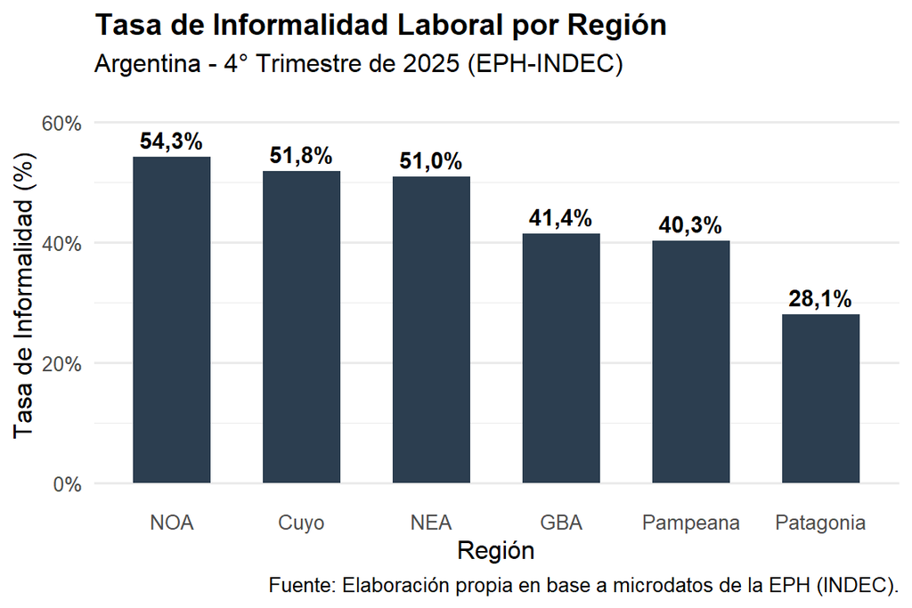

#### Análisis de la Brecha de Género e Informalidad por Región

El análisis cruzado entre el territorio y la dimensión de género revela una penalización sistemática hacia las mujeres en todas las regiones del país.

En cada una de las seis regiones analizadas, la tasa de informalidad femenina supera a la masculina. En términos generales, las mujeres enfrentan una mayor probabilidad de inserción en puestos no registrados, lo que confirma la presencia de barreras estructurales vinculadas a la segregación ocupacional y a la inserción en sectores de baja productividad y alta informalidad. En este sentido, se observa una amplificación de la brecha en regiones de alta informalidad:

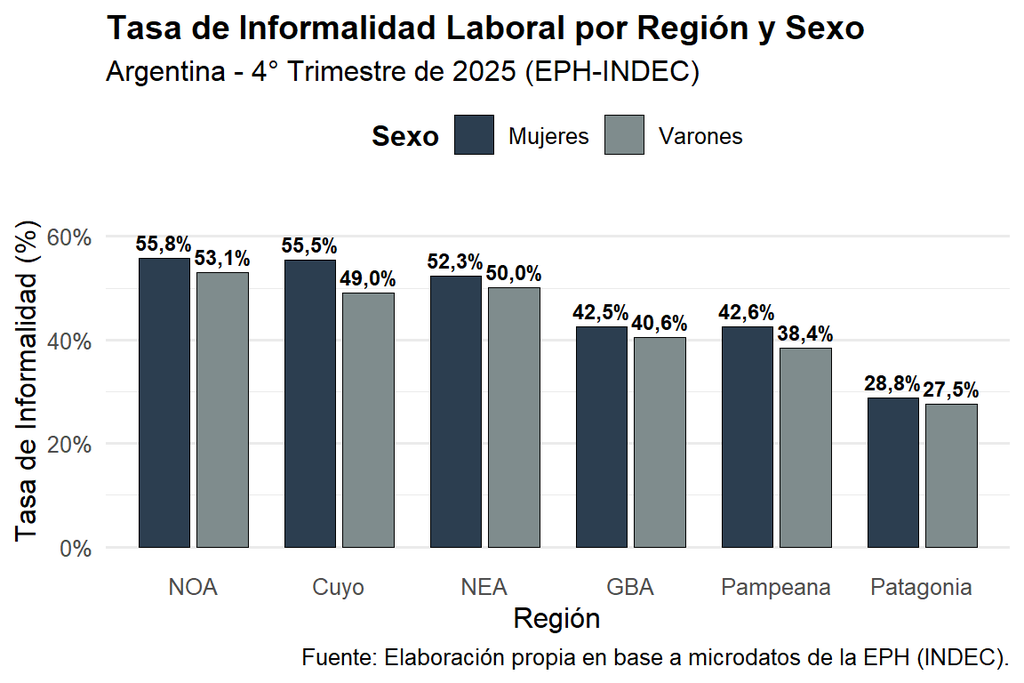

Este escenario expone que la mayor carga del trabajo no remunerado en el hogar limita la disponibilidad horaria de las mujeres, forzándolas a aceptar empleos informales con mayor flexibilidad pero desprovistos de seguridad social y derechos laborales básicos.

#### Analisis de la persistencia en la Informalidad

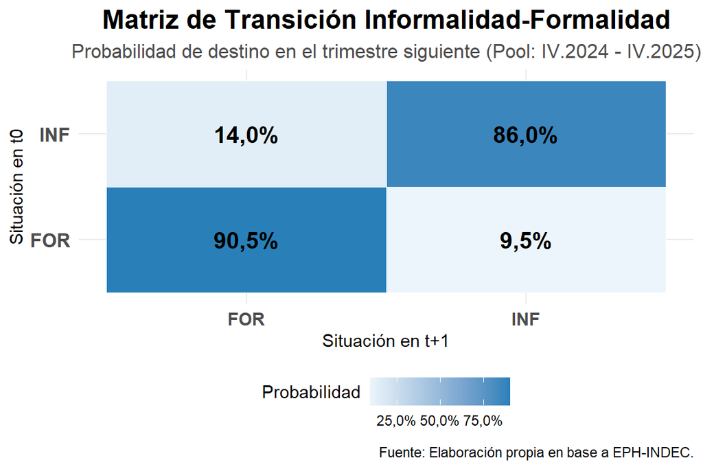

La imagen presenta una matriz de transición entre informalidad y formalidad laboral, elaborada a partir de datos de la Encuesta Permanente de Hogares (EPH-INDEC) para el período acumulado entre el cuarto trimestre de 2024 y el cuarto trimestre de 2025. Muestra la probabilidad de que un trabajador cambie o mantenga su condición de empleo (Formal/Informal) de un trimestre al siguiente.

Los valores diagonales ($86,0\%$ para la informalidad y $90,5\%$ para la formalidad) muestran que la condición laboral actual tiende a mantenerse con mucha fuerza en el corto plazo (de un trimestre a otro). A su vez, solo el $14,0\%$ de las personas que comienzan en una situación informal logran formalizarse al trimestre siguiente.

En términos de la dinámica trimestral, el género no genera brechas significativas en la velocidad de transición entre empleo formal e informal. La trampa de la informalidad (dificultad para formalizarse y alta persistencia en el sector informal) afecta por igual a hombres y mujeres una vez que ya se encuentran dentro de uno de esos estados.

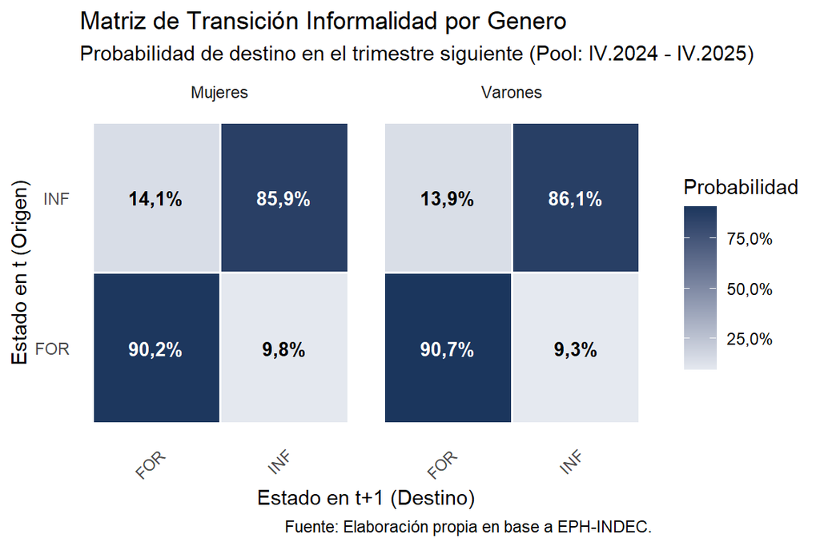

Sin embargo, el capital educativo altera de forma sustancial estas probabilidades. Los trabajadores con nivel educativo BAJO experimentan una verdadera “trampa de informalidad”, registrando una probabilidad del 90,8% de continuar en empleos no registrados y solo un 9,2% de acceder a la formalización en el trimestre posterior. Asimismo, este grupo presenta el mayor riesgo de precarización laboral, con una tasa de tránsito del sector formal al informal del 16,2%.

En contraste, la formación de NIVEL ALTO actúa tanto como un escudo protector como un canal de movilidad ascendente. Los ocupados con estudios superiores presentan una probabilidad de salida de la informalidad hacia la formalidad del 28,4% —más de tres veces superior a la de aquellos con nivel bajo— y logran retener su condición formal en un 94,2% de los casos, reduciendo el riesgo de informalización a un marginal 5,8%. De este modo, la evidencia confirma que la acumulación de capital humano reduce la vulnerabilidad laboral y resulta indispensable para mitigar la rigidez de la informalidad estructural.

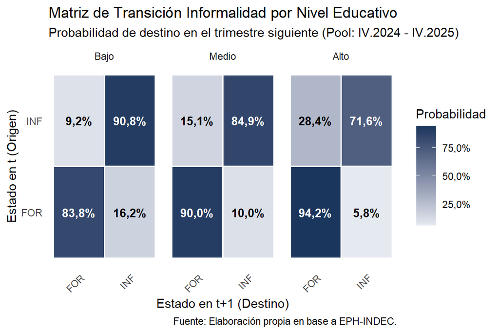

### Conclusion

El análisis de los microdatos de la Encuesta Permanente de Hogares (EPH) para el cuarto trimestre de 2025 pone de manifiesto que la informalidad laboral en la Argentina dista de ser una problemática homogénea o un fenómeno coyuntural; constituye un rasgo estructural, fuertemente condicionado por el territorio, el género, el capital humano y la inercia del propio mercado de trabajo.

En síntesis, abordar la informalidad en Argentina requiere superar las recetas agregadas y diseñar políticas públicas focalizadas. Es indispensable articular estrategias de desarrollo productivo regional, esquemas de inclusión en la economía del cuidado que reduzcan la brecha de género y programas integrales de formación continua que eleven el capital humano, rompiendo así el círculo vicioso entre baja productividad, inestabilidad laboral y falta de cobertura social.